# Bingo

Valerie Morrill

6/28/2023

# Estimating the probability of getting a bingo

To estimate the probability of getting a bingo after x numbers are called, we will make the following assumptions about the bingo game rules:

- the bingo-card is a standard 5x5 bingo card with 24 unique numbers distributed across the grid
- the bingo-card has a center free space
- x unique, random numbers between 1 and 75 are called
- to get a bingo, you must form a horizontal, vertical, or diagonal line

## We will use a simulation approach

```r
library(dplyr)
library(ggplot2)
```

### Write a function to create a random bingo-card

```r
create_bingo_card <- function() {
  # Initialize an empty matrix for the bingo-card
  card <- matrix(0, nrow = 5, ncol = 5)

  # Generate random numbers for each column
  for (col in 1:5) {
    # Calculate the range of numbers for the column
    min_num <- 15 * (col - 1) + 1
    max_num <- 15 * col

    # Sample 5 unique numbers for the column
    column_numbers <- sample(min_num:max_num, 5, replace = FALSE)

    # Assign the numbers to the bingo-card
    card[, col] <- column_numbers
  }

  # Return the generated bingo-card
  return(card)
}
```

### Create a random bingo-card

```r
bingo_card <- create_bingo_card()

# Print the bingo-card
print(bingo_card)
```

```
##      [,1] [,2] [,3] [,4] [,5]
## [1,]    5   19   37   60   66
## [2,]    3   25   33   56   63
## [3,]    1   17   31   49   67
## [4,]   11   22   36   57   73
## [5,]   10   18   39   52   74
```

### Write a function to create a record-card to mark the location of numbers called on your bingo-card

```r
create_record_card <- function() {

record_card <- matrix(FALSE, nrow = 5, ncol = 5)

# Replace the center number with TRUE (free blank space)
record_card[3, 3] <- TRUE

# Return the generated record-card
  return(record_card)
}
```

### Create a record-card

```r
record_card <- create_record_card()

# Print the record-card
print(record_card)
```

```
##       [,1]  [,2]  [,3]  [,4]  [,5]
## [1,] FALSE FALSE FALSE FALSE FALSE
## [2,] FALSE FALSE FALSE FALSE FALSE
## [3,] FALSE FALSE  TRUE FALSE FALSE
## [4,] FALSE FALSE FALSE FALSE FALSE
## [5,] FALSE FALSE FALSE FALSE FALSE
```

### Write a function to mark the location of numbers called on the record-card

```r
update_record_card <- function(number) {

if (number %in% bingo_card) {

#make bingo card a data frame
 t <- data.frame(bingo_card)

 #extract row and column location of number called
 location <- which(t==number,arr.ind=TRUE)
 row <- location[1,1]
 col <- location[1,2]

record_card[row,col] <- TRUE

}

return(record_card)

}
```

### Mark if we have 1, 2, 3 or 4 on the record card

```r
record_card<- update_record_card(1)
record_card<- update_record_card(2)
record_card<- update_record_card(3)
record_card<- update_record_card(4)
print(record_card)
```

```
##       [,1]  [,2]  [,3]  [,4]  [,5]
## [1,] FALSE FALSE FALSE FALSE FALSE
## [2,]  TRUE FALSE FALSE FALSE FALSE
## [3,]  TRUE FALSE  TRUE FALSE FALSE
## [4,] FALSE FALSE FALSE FALSE FALSE
## [5,] FALSE FALSE FALSE FALSE FALSE
```

### Write a function to check if a bingo is achieved

```r
check_bingo <- function(record_card) {
  # Check rows
  if (any(rowSums(record_card) == 5))
    return(TRUE)

  # Check columns
  if (any(colSums(record_card) == 5))
    return(TRUE)

  # Check diagonals
  if (sum(diag(record_card)) == 5 || sum(diag(apply(record_card, 2, rev))) == 5)
    return(TRUE)

  # No bingo
  return(FALSE)
}
```

### Check for a bingo

```r
check_bingo(record_card)
```

```
## [1] FALSE
```

### Call all the rest of the possible numbers in the first column, and then check for a bingo

```r
record_card<- update_record_card(5)
record_card<- update_record_card(6)
record_card<- update_record_card(7)
record_card<- update_record_card(8)
record_card<- update_record_card(9)
record_card<- update_record_card(10)
record_card<- update_record_card(11)
record_card<- update_record_card(12)
record_card<- update_record_card(13)
record_card<- update_record_card(14)
record_card<- update_record_card(15)
print(record_card)
```

```
##      [,1]  [,2]  [,3]  [,4]  [,5]
## [1,] TRUE FALSE FALSE FALSE FALSE
## [2,] TRUE FALSE FALSE FALSE FALSE
## [3,] TRUE FALSE  TRUE FALSE FALSE
## [4,] TRUE FALSE FALSE FALSE FALSE
## [5,] TRUE FALSE FALSE FALSE FALSE
```

```r
check_bingo(record_card)
```

```
## [1] TRUE
```

### Write a function to simulate a bingo game with x numbers called

```r
simulate_bingo <- function(x, bingo_card, record_card) {

        # Generate x random numbers between 1 and 75 without replacement (assuming a standard 75-ball bingo game)
        numbers <- sample(1:75, x, replace=FALSE)

        #For each number called
        for (i in numbers) {

                #if it is on the bingo card
                if (i %in% bingo_card) {

                        #extract row and column location of number called on the bingo card
                        t <- data.frame(bingo_card)
                        location <- which(t==i,arr.ind=TRUE)
                        row <- location[1,1]
                        col <- location[1,2]

                        #Mark that location on the record card
                        record_card[row,col] <- TRUE

                }

        }

#Check for a bingo
return(check_bingo(record_card))

}
```

### Simulate one bingo game with 30 numbers called. Did we get a bingo?

```r
# Create a random bingo-card
bingo_card <- create_bingo_card()
# Create a blank record-card
record_card <- create_record_card()

simulate_bingo(30, bingo_card, record_card)
```

```
## [1] TRUE
```

### Simulate 1000 bingo games with 30 numbers called. What proportion of games did we get a bingo?

```r
# Set the number of simulations
num_simulations <- 1000

# Set x numbers
x<- 30

# Initialize a counter for successful bingos
bingo_counter <- 0

# Run the simulations
for (i in 1:num_simulations) {

        # Create a random bingo-card
        bingo_card <- create_bingo_card()

        # Create a blank record-card
        record_card <- create_record_card()

        #if bingo is true, add one to the bingo counter
        if (simulate_bingo(x, bingo_card, record_card)) {
        bingo_counter <- bingo_counter + 1
        }
}

# Calculate the probability of getting a bingo after x numbers are called
probability <- bingo_counter / num_simulations

# Print the result
cat("Probability of getting a bingo after", x, " numbers are called:", probability, "\n")
```

```
## Probability of getting a bingo after 30  numbers are called: 0.141
```

### Simulate 1000 bingo games each with 1-75 numbers called. What proportion of games did we get a bingo?

```r
# Create a data frame to store the results
bingo_results <- data.frame(matrix(ncol = 2, nrow = 75))
colnames(bingo_results) <- c("number_of_numbers", "probability_of_bingo")

# Set the number of simulations
num_simulations <- 1000

#For each number called
for (x in 1:75) {

        # Initialize a counter for successful bingos
        bingo_counter <- 0

        #For each simulation
        for (i in 1:num_simulations) {


                # Create a random bingo-card
                bingo_card <- create_bingo_card()

                # Create a blank record-card
                record_card <- create_record_card()

                #if bingo is true, add one to the bingo counter
                if (simulate_bingo(x, bingo_card, record_card)) {
                bingo_counter <- bingo_counter + 1
                }

        #record the percent of bingos associated with the number of numbers called
        bingo_results[x,1]<- x
        bingo_results[x,2]<- bingo_counter / num_simulations
        }

}

# Print the result
bingo_results
```

```
##    number_of_numbers probability_of_bingo
## 1                  1                0.000
## 2                  2                0.000
## 3                  3                0.000
## 4                  4                0.000
## 5                  5                0.000
## 6                  6                0.000
## 7                  7                0.000
## 8                  8                0.000
## 9                  9                0.001
## 10                10                0.000
## 11                11                0.001
## 12                12                0.003
## 13                13                0.004
## 14                14                0.006
```

[output cut: 61 more lines]

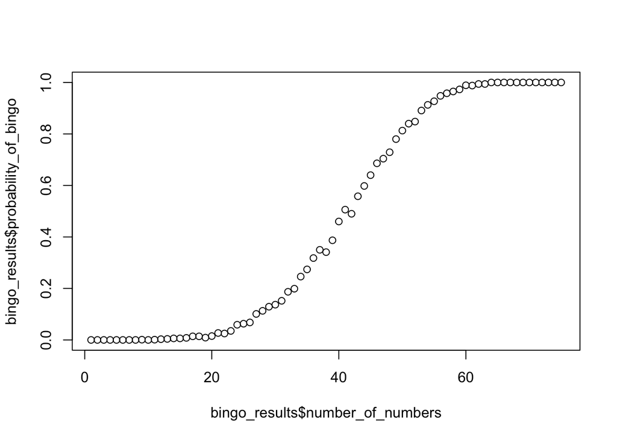

```r
# Plot the result

plot(bingo_results$number_of_numbers, bingo_results$probability_of_bingo)
```

### What if there are 18 people playing bingo?

### Simulate 1000 bingo games with 30 numbers called. What proportion of games did we get a bingo?

```r
# Set the number of simulations
num_simulations <- 1000

# Set x numbers
x<- 30

# Set the number of people
people <- 18

# Initialize a counter for successful bingos
bingo_counter <- 0

# Run the simulations
for (i in 1:num_simulations) {

        #For each person
              for (t in 1:people) {


                        # Create a random bingo-card
                        bingo_card <- create_bingo_card()

                        # Create a blank record-card
                        record_card <- create_record_card()

                        #If a person did not get bingo after x numbers were called, move to the next person
                        #If any person got bingo after x numbers are called,
                        #add one to the bingo counter and stop looping over people
                        if (!simulate_bingo(x, bingo_card, record_card)) {
                        bingo_counter <- bingo_counter + 0
                        } else {
                        bingo_counter <- bingo_counter + 1
                        break
                        }

                  }

}

# Calculate the probability of getting a bingo after x numbers are called
probability <- bingo_counter / num_simulations

# Print the result
cat("Probability of getting a bingo after", x, " numbers are called when there are ", people , "people:", probability, "\n")
```

```
## Probability of getting a bingo after 30  numbers are called when there are  18 people: 0.936
```

```r
# Create a data frame to store the results
bingo_results <- data.frame(matrix(ncol = 2, nrow = 75))
colnames(bingo_results) <- c("number_of_numbers", "probability_of_bingo")

# Set the number of simulations
num_simulations <- 500

# Set the number of people
people <- 18

# For each number called
for (x in 1:75) {

        # Initialize a counter for successful bingos
        bingo_counter <- 0

        # For each simulation
        for (i in 1:num_simulations) {

                for (t in 1:people) {


                        # Create a random bingo-card
                        bingo_card <- create_bingo_card()

                        # Create a blank record-card
                        record_card <- create_record_card()

                        #If a person did not get bingo after x numbers were called, move to the next person
                        #If any person got bingo after x numbers are called, add one to the bingo counter and stop looping over people
                        if (!simulate_bingo(x, bingo_card, record_card)) {
                        bingo_counter <- bingo_counter + 0
                        } else {
                        bingo_counter <- bingo_counter + 1
                        break
                        }

                  }




        }

        #record the percent of bingos associated with the number of numbers called
        bingo_results[x,1]<- x
        bingo_results[x,2]<- bingo_counter / num_simulations
}



# Print the result
bingo_results
```

```
##    number_of_numbers probability_of_bingo
## 1                  1                0.000
## 2                  2                0.000
## 3                  3                0.000
## 4                  4                0.000
## 5                  5                0.002
## 6                  6                0.002
## 7                  7                0.000
## 8                  8                0.006
## 9                  9                0.014
## 10                10                0.016
## 11                11                0.016
## 12                12                0.042
## 13                13                0.040
## 14                14                0.072
```

[output cut: 61 more lines]

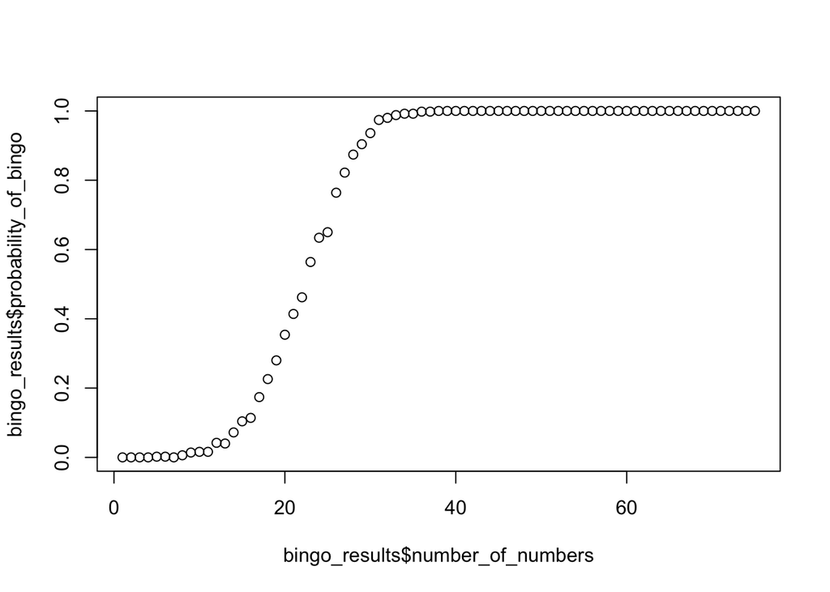

```r
# Plot the result

plot(bingo_results$number_of_numbers, bingo_results$probability_of_bingo)
```